# 2.2.2 HT1080 LOY vs sgCTRL — RNA-seq extended (robustness layer)

# Overview

**Extended** HT1080 LOY-vs-sgCTRL analysis — robustness layer on top of the canonical base report (`2.2.1_rnaseq_HT1080_base.Rmd`). Same count matrix, same samples, additional sanity-checks and alternative framings designed to answer “would the conclusions change if we’d made different statistical choices?”.

Every DE-centric section now covers **three contrast designs side-by-side** where appropriate, so the choice of baseline (sgCTRL paired by passage, sgCTRL unpaired, or PARENTAL + sgCTRL pooled as Y+) is itself a robustness axis rather than a hidden assumption.

**Counts pipeline.** Counts come from `STAR_v2_PARfix/AUG_2025_HT1080_LOY/` — a PAR-Y-masked STAR realignment + featureCounts re-quantification done specifically to recover chrX-PAR reads that the original AUG_2025 STAR run silently dropped at multi-mapper filtering. MSY (true chrY) counts are unchanged; PAR1/PAR2 counts (SHOX, CSF2RA, SLC25A6, etc.) are now non-zero. Y-region annotation lives in §1.4.5; the Y/PAR-retaining volcano is §4.0; the §11 LOY-transcriptomics summary now produces real PAR signature scores.

1. **Filter-threshold sensitivity** (§2). Sweep `MIN_COUNT ∈ {50, 100, 200}` on the paired design (the design of record), report DEG and Hallmark NES concordance across thresholds, pick the threshold used downstream. The design-choice axis (paired / unpaired / pooled) is addressed in §4/§5/§6 and the §10 robustness summary, where it actually shapes the result.
2. **voom diagnostics + sample weights** (§3). Mean-variance plot and `voomWithQualityWeights` for sample-reliability auditing on 3v3 data (paired, design-of-record).
3. **Effect-size-aware DE with `treat()`** (§4). Tested against the lfc threshold across all 3 designs.
4. **edgeR quasi-likelihood cross-check** (§5). `glmQLFTest` as a second statistical framework across all 3 designs.
5. **`camera` gene-set testing** (§6). Competitive, correlation-aware side-by-side with fgsea, across all 3 designs.
6. **Sex-chromosome homologs / Y-linked paralog deep-dive** (§7). KDM5D/C, UTY/KDM6A, DDX3Y/X, RPS4Y1/X, EIF1AY/X, ZFY/X, TMSB4Y/X, USP9Y/X, PRKY/X, NLGN4Y/X — dosage compensation analysis (paired, design-independent at the per-sample level).
7. **Sample-level pathway scoring** (§8). GSVA / ssGSEA Hallmark, PROGENy, decoupleR-PROGENy, and custom LOY/PRC2/chrY signatures. Sample scoring is design-independent; the LM significance test at the end is run across all 3 designs.
8. **lpWGS copy-number integration** (§9). Gene-level CN from HT1080 QDNAseq on T2T-CHM13, DEG annotation (canonical paired), chromosome-arm shifts, CN-flagged DEG sensitivity rerun across all 3 designs in §9.9, Y-loss confirmation panel (lpWGS + RNA).
9. **Robustness summary** (§10). Combined DEG table across all statistical pipelines × all designs + CN + paralog flags; “confident DEG” call.

Notation: HT1080 = NRAS Q61K fibrosarcoma; CTRL = sgRNA non-targeting control (Y+); LOY = Y-chromosome–targeting sgRNA (Y−); PARENTAL retained for QC and the **pooled** Y+ baseline (LOY vs PARENTAL + sgCTRL).

# 1. Setup

## 1.1 Load packages

## 1.2 Paths and figure helper

## 1.3 Sample metadata + counts

HT1080 Sample Summary (n=9)

| treatment | n | replicates |
| --- | --- | --- |
| CTRL | 3 | 1, 2, 3 |
| LOY | 3 | 1, 2, 3 |
| PARENTAL | 3 | 1, 2, 3 |

```
## Loaded 78899 genes across 9 samples
```

## 1.4 Build DGEList scaffold (no filtering yet)

```
## Genes with full annotation: 24356
```

## 1.4.5 Y-region annotation (PAR1 / PAR2 / MSY-Yp / MSY-Yq)

GRCh38 PAR coordinates (Ensembl/GENCODE). PAR genes are annotated on chrX only (chrY PAR positions are masked at the annotation level), so PAR identification scans chrX. MSY = remaining chrY genes (non-PAR), split into Yp / Yq by the chrY centromere midpoint (~10.43 Mb, UCSC).

Two filter sets are exposed downstream:

- **`chrY_gene_ids`** (MSY only) — stripped from the DGEList before differential expression (§2 filter sweep, §4 treat-helpers). PAR genes stay so they get logFC + FDR like every other gene in §4.1+ volcanos.
- **`excluded_gene_ids`** (chrY ∪ PAR) — stripped at every pathway-input boundary: `prep_ranks()` in the sweep chunk; camera voom rows in §6; ssGSEA / PROGENy / decoupleR lcpm matrices in §8; CN-sensitivity rerun in §9.9 (via `prep_ranks`). Camera/GSVA/decoupleR are gene-set / TF tests where PAR LOY signal would distort the result (it’s library- composition artefact, not biology).

```
## Y-region panel: 113 genes  [PAR1=20, PAR2=3, MSY-Yp=35, MSY-Yq=55]
```

```
## Exclusion set for pathway analyses: 113 genes (chrY ∪ PAR)
```

## 1.5 Multi-design DE infrastructure

The robustness sections (§2 filter sweep, §4 treat, §5 edgeR-QL, §6 camera, §8.6 LM tests, §9.9 CN-flagged rerun, §10 robustness summary) all run the same three DE designs side-by-side. Defining the design specifications once keeps the downstream code mechanical.

```
## Design specs registered: paired, unpaired, pooled
```

# 2. Filter-threshold sensitivity sweep

`filterByExpr(min.total.count = ?)` with `MIN_COUNT ∈ {50, 100, 200}`. For each, build the LOY+CTRL working set, refit paired limma–voom DE, capture DEG counts, and run fgsea on Hallmark.

```
## Loading Hallmark for sweep...
```

```
##
## --- MIN_COUNT = 50 ---
##   After filter: 16015 genes; 6 samples
##
## --- MIN_COUNT = 100 ---
##   After filter: 15439 genes; 6 samples
##
## --- MIN_COUNT = 200 ---
##   After filter: 14384 genes; 6 samples
```

## 2.1 Summary table

Filter-threshold sweep — tested genes, DEGs, GSEA hits

| MIN_COUNT | n_tested | n_FDR_0.05 | n_FDR_0.05_&_\|lfc\|>0.75 | n_hallmark_padj_0.05 |
| --- | --- | --- | --- | --- |
| 50 | 16015 | 1149 | 524 | 21 |
| 100 | 15439 | 1128 | 517 | 20 |
| 200 | 14384 | 1116 | 499 | 18 |

## 2.2 Gene-set overlap across thresholds

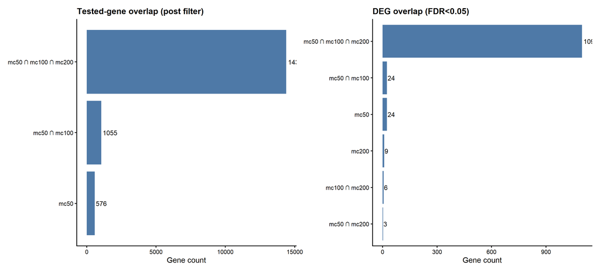

```
## Saved: sweep_overlap.(png|pdf)  [11x5 in]
```

## 2.3 Hallmark NES concordance across thresholds

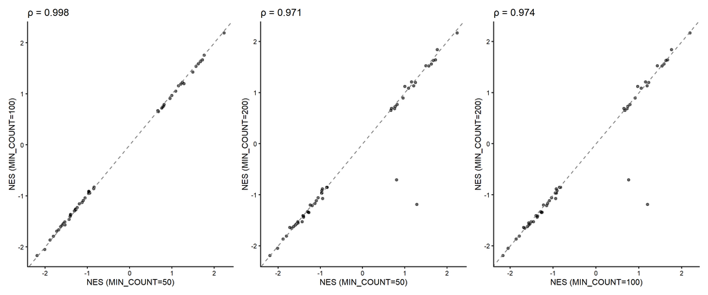

```
## Saved: sweep_hallmark_NES_concordance.(png|pdf)  [12x5 in]
```

## 2.4 Save sweep + pick working threshold

```
##
## >>> Using MIN_COUNT = 50 for §3 onward.
```

# 3. voom diagnostics + sample weights

## 3.1 Standard voom mean-variance

`voom(..., plot = TRUE)` draws its own “Mean-variance trend” title; the single-panel mean-variance figure fits comfortably at 6×5 in.

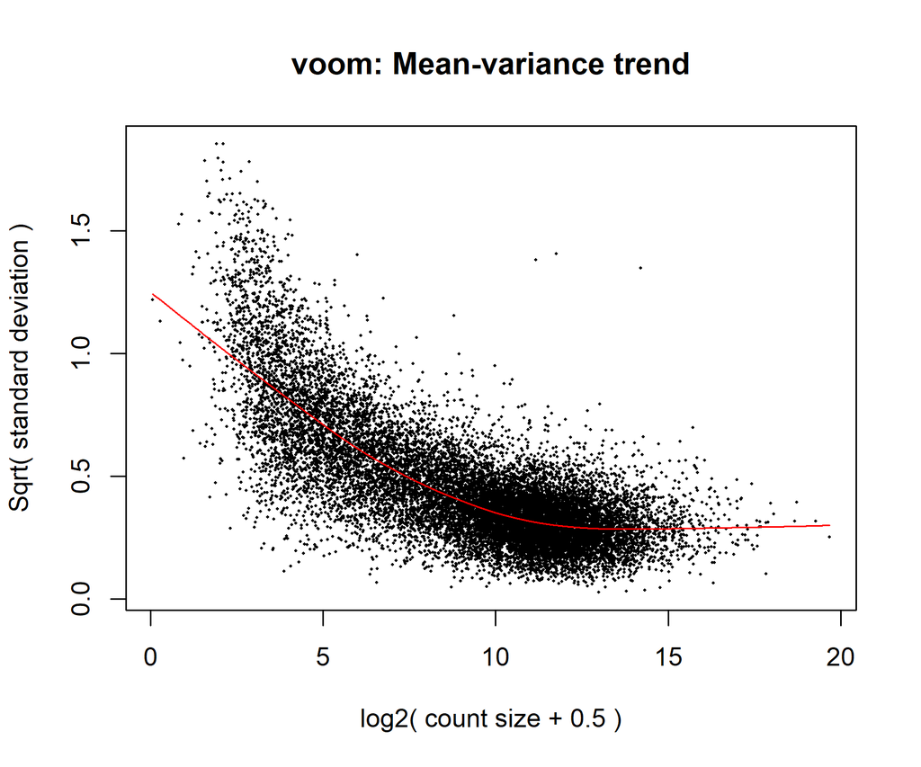

## 3.2 voomWithQualityWeights (sample weights)

`voomWithQualityWeights(..., plot = TRUE)` draws a **two-panel** layout (mean-variance on the left, per-sample weights on the right) — needs a wider canvas than the single-panel §3.1 to keep both panels readable.

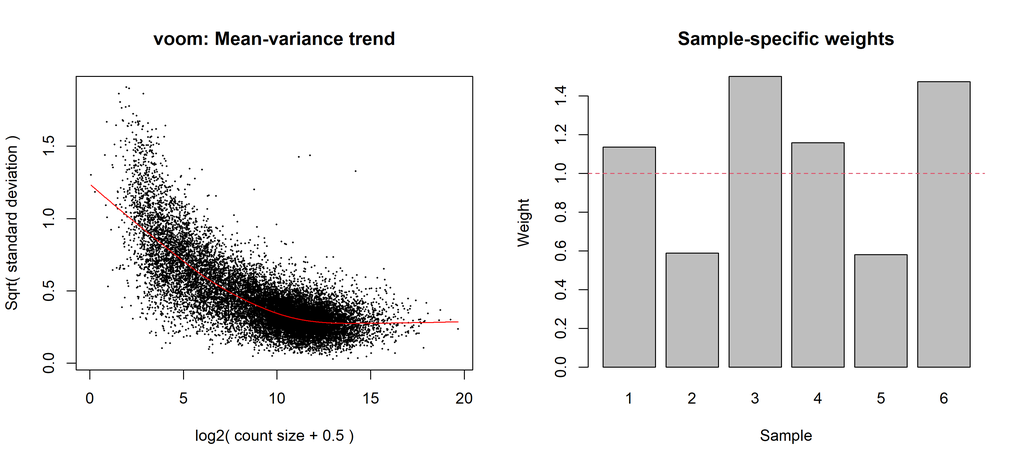

## 3.3 Per-sample weights table

Per-sample voomQW sample weights

| sample | treatment | passage | lib.size | norm.factors | sample_weight | lib.size_M |
| --- | --- | --- | --- | --- | --- | --- |
| HT1080-CTRL-1 | CTRL | 1 | 62651511 | 0.9844739 | 1.136 | 62.7 |
| HT1080-CTRL-2 | CTRL | 2 | 61306694 | 1.0178193 | 0.590 | 61.3 |
| HT1080-CTRL-3 | CTRL | 3 | 62577274 | 1.0090345 | 1.502 | 62.6 |
| HT1080-LOY-1 | LOY | 1 | 57593749 | 0.9922091 | 1.158 | 57.6 |
| HT1080-LOY-2 | LOY | 2 | 57439240 | 0.9949689 | 0.582 | 57.4 |
| HT1080-LOY-3 | LOY | 3 | 62132018 | 1.0018585 | 1.475 | 62.1 |

## 3.4 Weight visualization

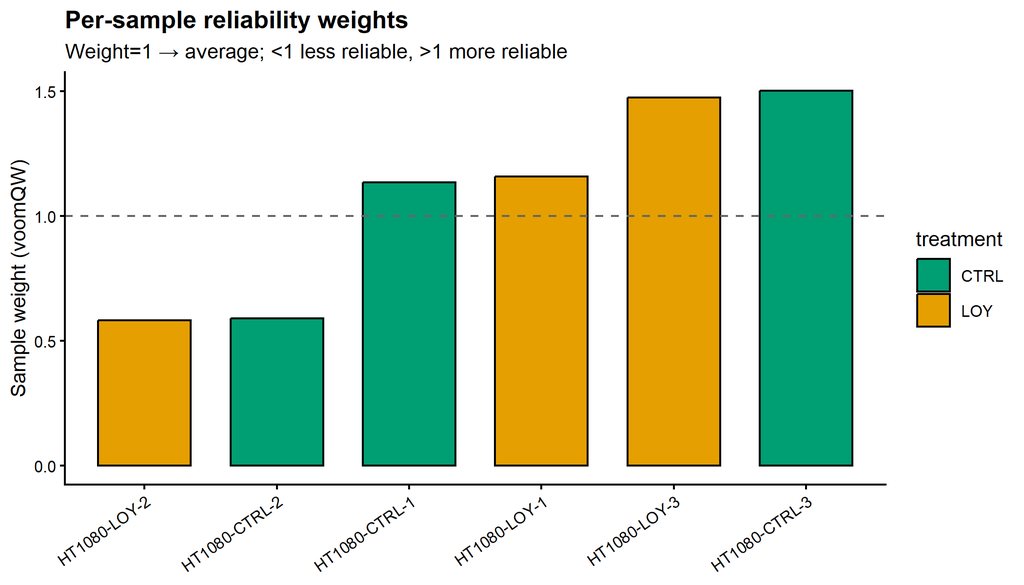

```
## Saved: voomQW_sample_weights.(png|pdf)  [7x4 in]
```

## 3.5 voom vs voomQW concordance

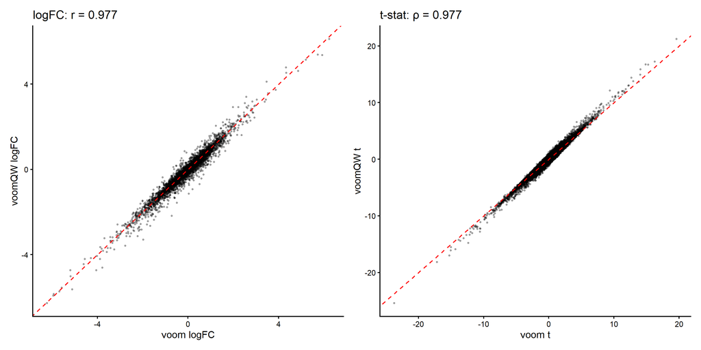

```
## Saved: voom_vs_voomQW_concordance.(png|pdf)  [10x5 in]
```

# 4. Effect-size-aware DE with `treat()`

`treat()` tests `|logFC| > LFC_THR` instead of `≠ 0`. This is what the post-hoc filter in the canonical report tried to approximate, but treat does it inside the test — giving correct p-values for the effect-size question. Run side-by-side on all three designs (paired / unpaired / pooled) so the choice of baseline is itself a robustness axis.

treat() — sig DEG counts by design (HT1080)

| design | n_FDR_0.05 | n_FDR_0.05_up | n_FDR_0.05_down |
| --- | --- | --- | --- |
| paired | 57 | 20 | 37 |
| unpaired | 0 | 0 | 0 |
| pooled | 3 | 3 | 0 |

## 4.0 Y-region volcano (pre-strip)

A LOY-vs-sgCTRL paired DE run on a **Y-retaining and PAR-retaining** working set (mirror of `dge0_full` above but skips the `excluded_gene_ids` strip). Every chrY (MSY-Yp / MSY-Yq) and chrX-PAR (PAR1 / PAR2) gene that passes filterByExpr appears with a real `logFC` + `FDR` value — so the volcano shows what the LOY perturbation does to the Y-linked + PAR expression landscape before §4.1+ strips those genes for downstream pathway analysis.

This view was previously impossible because the upstream STAR pipeline dropped PAR multi-mappers (all PAR genes had ~0 reads). Now that `STAR_v2_PARfix` counts are loaded (see §1.2), PAR genes have real values.

```
## Y-retaining paired DE: 16027 genes tested
```

```
##   Y-region genes: 28  [PAR1=13, PAR2=3, MSY-Yp=3, MSY-Yq=9]
```

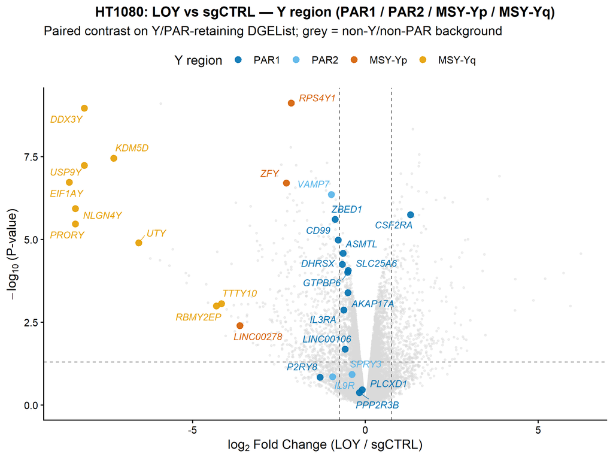

```
## Saved: volcano_LOY_v_sgCTRL_yregion.(png|pdf)  [8x6 in]
```

## 4.1 treat volcano (by design)

### Paired

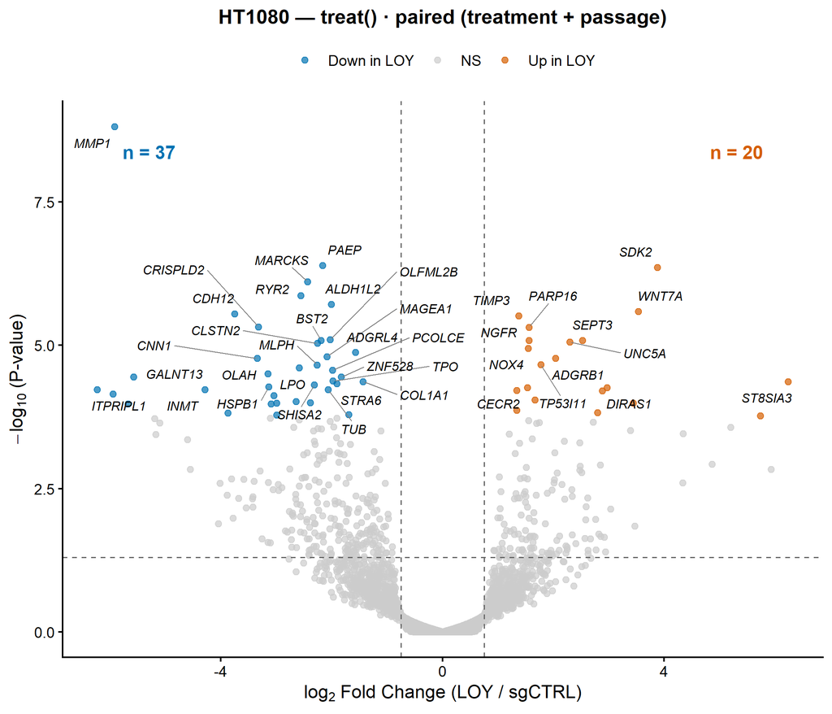

```
## Saved: volcano_treat_paired.(png|pdf)  [7x6 in]
```

### Unpaired

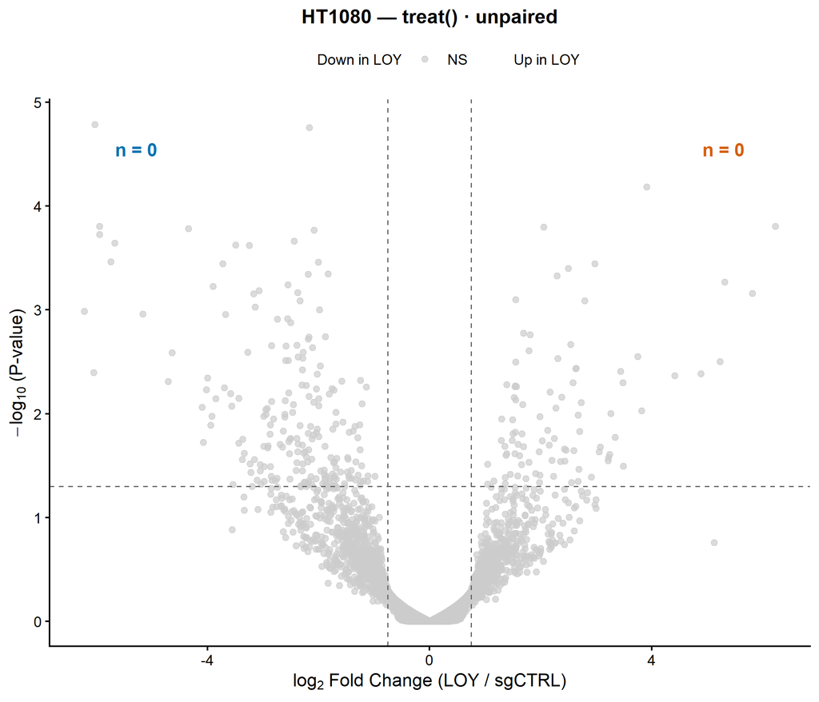

```
## Saved: volcano_treat_unpaired.(png|pdf)  [7x6 in]
```

### Pooled

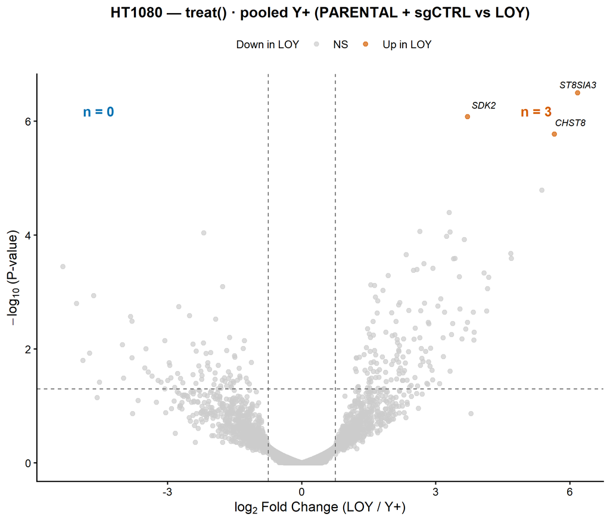

```
## Saved: volcano_treat_pooled.(png|pdf)  [7x6 in]
```

## 4.2 treat-significant vs post-hoc filtered overlap (paired)

The standard comparison: does `treat()` (effect-size-aware test) recover the same DEGs as the canonical voom + post-hoc `|lfc|>0.75` filter on the paired design? Run on paired only — the design choice is independent of the treat-vs-post-hoc comparison.

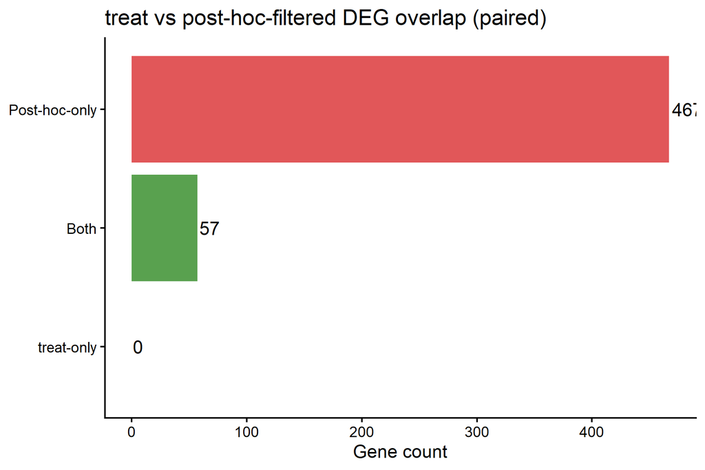

```
## Saved: treat_vs_posthoc_overlap_paired.(png|pdf)  [6x4 in]
```

## 4.3 Cross-design DEG overlap (treat)

How much of the canonical paired-treat DEG set is recovered by the unpaired and pooled designs? Strong overlap means the LOY effect is reproducible across baseline choice.

treat() DEG overlap with paired (anchor) — per design

| design | this_only | both_vs_paired | paired_only_vs_this |
| --- | --- | --- | --- |
| paired | 0 | 57 | 0 |
| unpaired | 0 | 0 | 57 |
| pooled | 1 | 2 | 55 |

# 5. edgeR quasi-likelihood cross-check

Second statistical framework on each of the three designs — voom/limma’s gaussian-on-logCPM vs edgeR’s negative-binomial-with-QL. Convergent signal across both frameworks for the same design is the strongest evidence that the LOY effect is real.

edgeR-QL sig DEG counts by design (HT1080)

| design | n_FDR_0.05 | n_FDR_0.05_&_lfc>thr |
| --- | --- | --- |
| paired | 1249 | 617 |
| unpaired | 54 | 54 |
| pooled | 80 | 79 |

## 5.1 BCV plot (by design)

### Paired

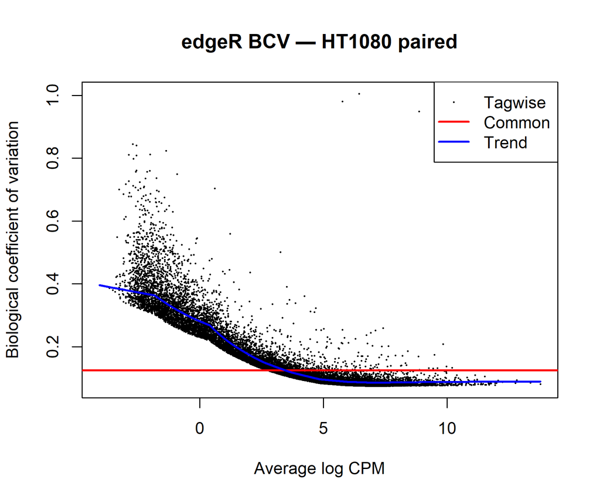

### Unpaired

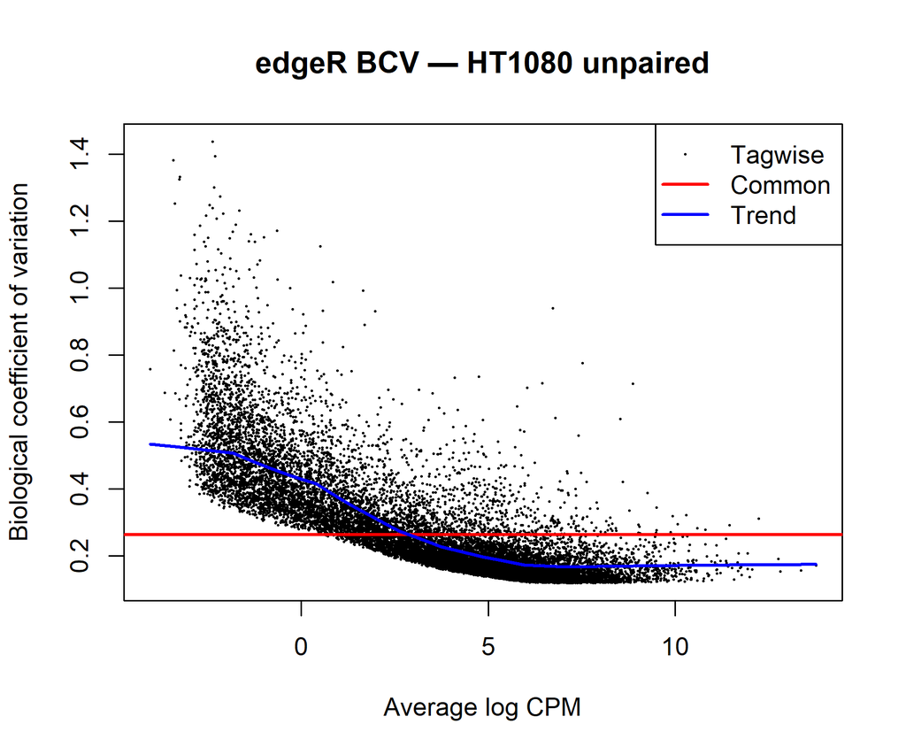

### Pooled

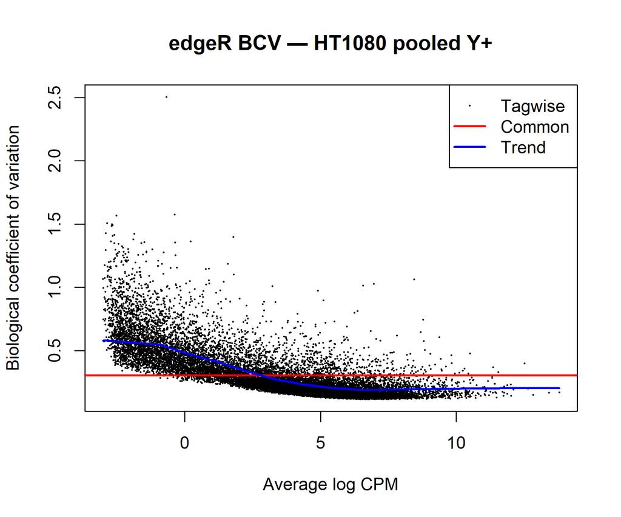

## 5.2 QL t-stat concordance with voom (by design)

### Paired

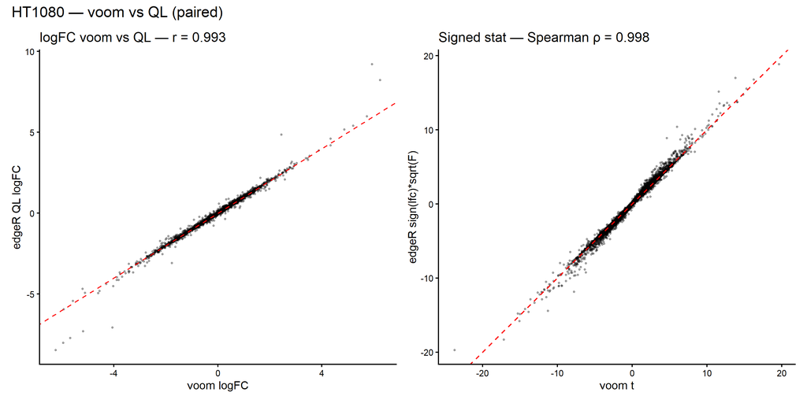

```
## Saved: voom_vs_QL_concordance_paired.(png|pdf)  [10x5 in]
```

### Unpaired

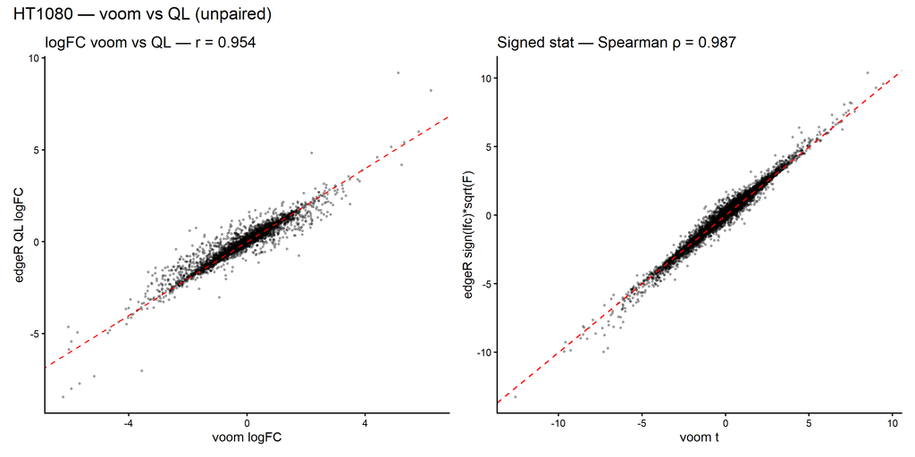

```
## Saved: voom_vs_QL_concordance_unpaired.(png|pdf)  [10x5 in]
```

### Pooled

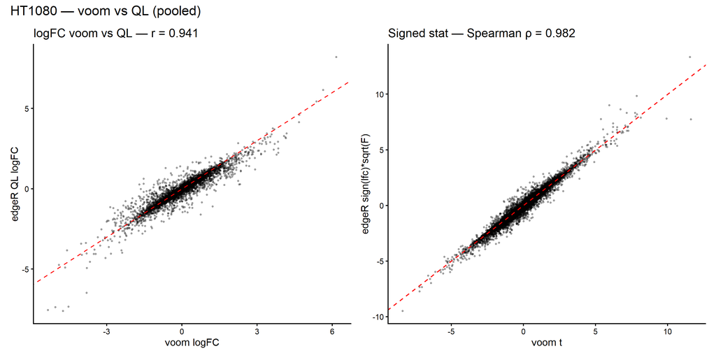

```
## Saved: voom_vs_QL_concordance_pooled.(png|pdf)  [10x5 in]
```

## 5.3 Top-200 DEG overlap (per design)

Top-200 voom ∩ top-200 QL per design (n out of 200)

| design | intersect | pct |
| --- | --- | --- |
| paired | 179 | 89.5% |
| unpaired | 171 | 85.5% |
| pooled | 169 | 84.5% |

# 6. `camera` gene-set testing

`camera` is a competitive gene-set test that accounts for inter-gene correlation — a complement to the (rank-based, correlation-naive) fgsea results in the canonical report’s §5.

```
## Loading MSigDB collections for camera...
```

camera FDR<0.05 hits by design × collection (HT1080)

| design | hallmark_sig | cgp_sig | reactome_sig |
| --- | --- | --- | --- |
| paired | 5 | 172 | 44 |
| unpaired | 4 | 69 | 9 |
| pooled | 9 | 167 | 31 |

## 6.1 camera vs fgsea: Hallmark side-by-side (by design)

### Paired

Top-25 Hallmark sets: camera vs fgsea (paired)

| pathway | camera_Dir | camera_FDR | camera_PValue | NES | padj_fgsea | agree |
| --- | --- | --- | --- | --- | --- | --- |
| HALLMARK_INTERFERON_ALPHA_RESPONSE | Down | 0.0000 | 0.0000 | -2.1916 | 0.0000 | agree Down |
| HALLMARK_E2F_TARGETS | Up | 0.0002 | 0.0000 | 2.2340 | 0.0000 | agree Up |
| HALLMARK_INTERFERON_GAMMA_RESPONSE | Down | 0.0014 | 0.0001 | -2.0106 | 0.0000 | agree Down |
| HALLMARK_INFLAMMATORY_RESPONSE | Down | 0.0174 | 0.0016 | -1.8017 | 0.0002 | agree Down |
| HALLMARK_ANGIOGENESIS | Down | 0.0174 | 0.0017 | -1.7247 | 0.0139 | agree Down |
| HALLMARK_SPERMATOGENESIS | Up | 0.0750 | 0.0090 | 1.7657 | 0.0041 | agree Up |
| HALLMARK_HYPOXIA | Up | 0.0859 | 0.0120 | 1.6745 | 0.0016 | agree Up |
| HALLMARK_EPITHELIAL_MESENCHYMAL_TRANSITION | Down | 0.0976 | 0.0156 | -1.8809 | 0.0001 | agree Down |
| HALLMARK_G2M_CHECKPOINT | Up | 0.1019 | 0.0203 | 1.7242 | 0.0003 | agree Up |
| HALLMARK_UNFOLDED_PROTEIN_RESPONSE | Down | 0.1019 | 0.0204 | -1.6340 | 0.0063 | agree Down |
| HALLMARK_MITOTIC_SPINDLE | Up | 0.1048 | 0.0231 | 1.6271 | 0.0017 | agree Up |
| HALLMARK_GLYCOLYSIS | Up | 0.1302 | 0.0312 | 1.5674 | 0.0049 | agree Up |
| HALLMARK_COMPLEMENT | Down | 0.2016 | 0.0524 | -1.5332 | 0.0066 | agree Down |
| HALLMARK_IL6_JAK_STAT3_SIGNALING | Down | 0.2288 | 0.0674 | -1.4098 | 0.0588 | agree Down |
| HALLMARK_TGF_BETA_SIGNALING | Down | 0.2288 | 0.0686 | -1.3055 | 0.2086 | agree Down |
| HALLMARK_CHOLESTEROL_HOMEOSTASIS | Up | 0.2551 | 0.0844 | -1.0979 | 0.4562 | disagree |
| HALLMARK_XENOBIOTIC_METABOLISM | Down | 0.2551 | 0.0867 | -1.4316 | 0.0235 | agree Down |
| HALLMARK_ALLOGRAFT_REJECTION | Down | 0.2832 | 0.1038 | -1.3963 | 0.0450 | agree Down |
| HALLMARK_COAGULATION | Down | 0.2832 | 0.1081 | -1.6767 | 0.0041 | agree Down |
| HALLMARK_APOPTOSIS | Down | 0.2832 | 0.1133 | -1.5651 | 0.0074 | agree Down |
| HALLMARK_IL2_STAT5_SIGNALING | Down | 0.3491 | 0.1466 | -1.3979 | 0.0235 | agree Down |
| HALLMARK_ESTROGEN_RESPONSE_LATE | Up | 0.3712 | 0.1633 | 1.4943 | 0.0106 | agree Up |
| HALLMARK_BILE_ACID_METABOLISM | Up | 0.4111 | 0.1964 | 1.1576 | 0.3318 | agree Up |
| HALLMARK_KRAS_SIGNALING_UP | Down | 0.4111 | 0.1974 | -1.5288 | 0.0063 | agree Down |
| HALLMARK_PROTEIN_SECRETION | Down | 0.4320 | 0.2160 | -0.8388 | 0.9314 | agree Down |

```
## Direction agreement: 41 / 50
```

### Unpaired

Top-25 Hallmark sets: camera vs fgsea (unpaired)

| pathway | camera_Dir | camera_FDR | camera_PValue | NES | padj_fgsea | agree |
| --- | --- | --- | --- | --- | --- | --- |
| HALLMARK_INTERFERON_ALPHA_RESPONSE | Down | 0.0001 | 0.0000 | -2.1855 | 0.0000 | agree Down |
| HALLMARK_INTERFERON_GAMMA_RESPONSE | Down | 0.0011 | 0.0000 | -2.0920 | 0.0000 | agree Down |
| HALLMARK_INFLAMMATORY_RESPONSE | Down | 0.0169 | 0.0010 | -1.8629 | 0.0001 | agree Down |
| HALLMARK_E2F_TARGETS | Up | 0.0481 | 0.0038 | 1.6717 | 0.0010 | agree Up |
| HALLMARK_ANGIOGENESIS | Down | 0.0986 | 0.0099 | -1.5490 | 0.0918 | agree Down |
| HALLMARK_HYPOXIA | Up | 0.2515 | 0.0302 | 1.4573 | 0.0298 | agree Up |
| HALLMARK_ALLOGRAFT_REJECTION | Down | 0.3218 | 0.0451 | -1.6062 | 0.0109 | agree Down |
| HALLMARK_SPERMATOGENESIS | Up | 0.3408 | 0.0545 | 1.4035 | 0.1116 | agree Up |
| HALLMARK_IL6_JAK_STAT3_SIGNALING | Down | 0.3651 | 0.0701 | -1.3781 | 0.1318 | agree Down |
| HALLMARK_EPITHELIAL_MESENCHYMAL_TRANSITION | Down | 0.3651 | 0.0753 | -1.5051 | 0.0269 | agree Down |
| HALLMARK_COAGULATION | Down | 0.3651 | 0.0850 | -1.6099 | 0.0269 | agree Down |
| HALLMARK_UNFOLDED_PROTEIN_RESPONSE | Down | 0.3651 | 0.0954 | -1.3452 | 0.1318 | agree Down |
| HALLMARK_COMPLEMENT | Down | 0.3651 | 0.1107 | -1.3948 | 0.0752 | agree Down |
| HALLMARK_XENOBIOTIC_METABOLISM | Down | 0.3651 | 0.1114 | -1.4310 | 0.0395 | agree Down |
| HALLMARK_TGF_BETA_SIGNALING | Down | 0.3651 | 0.1178 | -1.2308 | 0.3298 | agree Down |
| HALLMARK_GLYCOLYSIS | Up | 0.3651 | 0.1213 | 1.2218 | 0.1820 | agree Up |
| HALLMARK_APOPTOSIS | Down | 0.3651 | 0.1241 | -1.5448 | 0.0269 | agree Down |
| HALLMARK_CHOLESTEROL_HOMEOSTASIS | Up | 0.3837 | 0.1381 | 1.0419 | 0.6382 | agree Up |
| HALLMARK_MITOTIC_SPINDLE | Up | 0.4618 | 0.1755 | 1.0619 | 0.4907 | agree Up |
| HALLMARK_IL2_STAT5_SIGNALING | Down | 0.4805 | 0.1922 | -1.3108 | 0.1145 | agree Down |
| HALLMARK_KRAS_SIGNALING_UP | Down | 0.5138 | 0.2158 | -1.4554 | 0.0395 | agree Down |
| HALLMARK_UV_RESPONSE_DN | Down | 0.5192 | 0.2284 | -1.5016 | 0.0298 | agree Down |
| HALLMARK_BILE_ACID_METABOLISM | Up | 0.5267 | 0.2423 | 1.0204 | 0.6382 | agree Up |
| HALLMARK_TNFA_SIGNALING_VIA_NFKB | Down | 0.5404 | 0.2711 | -1.1621 | 0.3191 | agree Down |
| HALLMARK_FATTY_ACID_METABOLISM | Up | 0.5404 | 0.2777 | 1.0731 | 0.4907 | agree Up |

```
## Direction agreement: 45 / 50
```

### Pooled

Top-25 Hallmark sets: camera vs fgsea (pooled)

| pathway | camera_Dir | camera_FDR | camera_PValue | NES | padj_fgsea | agree |
| --- | --- | --- | --- | --- | --- | --- |
| HALLMARK_EPITHELIAL_MESENCHYMAL_TRANSITION | Down | 0.0002 | 0.0000 | -2.2742 | 0.0000 | agree Down |
| HALLMARK_INTERFERON_ALPHA_RESPONSE | Down | 0.0008 | 0.0000 | -2.4342 | 0.0000 | agree Down |
| HALLMARK_INTERFERON_GAMMA_RESPONSE | Down | 0.0031 | 0.0002 | -2.2291 | 0.0000 | agree Down |
| HALLMARK_ANGIOGENESIS | Down | 0.0091 | 0.0007 | -2.0019 | 0.0008 | agree Down |
| HALLMARK_TGF_BETA_SIGNALING | Down | 0.0255 | 0.0034 | -1.7627 | 0.0046 | agree Down |
| HALLMARK_E2F_TARGETS | Up | 0.0255 | 0.0036 | 1.8001 | 0.0001 | agree Up |
| HALLMARK_INFLAMMATORY_RESPONSE | Down | 0.0255 | 0.0036 | -1.8616 | 0.0000 | agree Down |
| HALLMARK_TNFA_SIGNALING_VIA_NFKB | Down | 0.0334 | 0.0054 | -1.7482 | 0.0002 | agree Down |
| HALLMARK_UV_RESPONSE_DN | Down | 0.0499 | 0.0090 | -1.7865 | 0.0005 | agree Down |
| HALLMARK_COAGULATION | Down | 0.0543 | 0.0109 | -1.7490 | 0.0020 | agree Down |
| HALLMARK_SPERMATOGENESIS | Up | 0.0815 | 0.0186 | 1.5661 | 0.0269 | agree Up |
| HALLMARK_APOPTOSIS | Down | 0.0815 | 0.0196 | -1.7284 | 0.0009 | agree Down |
| HALLMARK_COMPLEMENT | Down | 0.1086 | 0.0282 | -1.5470 | 0.0038 | agree Down |
| HALLMARK_ALLOGRAFT_REJECTION | Down | 0.1529 | 0.0428 | -1.7467 | 0.0009 | agree Down |
| HALLMARK_PROTEIN_SECRETION | Down | 0.1641 | 0.0492 | -1.1979 | 0.3242 | agree Down |
| HALLMARK_IL6_JAK_STAT3_SIGNALING | Down | 0.1692 | 0.0542 | -1.3382 | 0.1404 | agree Down |
| HALLMARK_ANDROGEN_RESPONSE | Down | 0.2325 | 0.0790 | -1.5392 | 0.0157 | agree Down |
| HALLMARK_IL2_STAT5_SIGNALING | Down | 0.4111 | 0.1480 | -1.2318 | 0.1160 | agree Down |
| HALLMARK_G2M_CHECKPOINT | Up | 0.5022 | 0.1908 | 1.0747 | 0.5354 | agree Up |
| HALLMARK_MYC_TARGETS_V2 | Up | 0.5187 | 0.2137 | 1.0749 | 0.5906 | agree Up |
| HALLMARK_ESTROGEN_RESPONSE_EARLY | Up | 0.5187 | 0.2178 | 1.3310 | 0.1218 | agree Up |
| HALLMARK_PEROXISOME | Down | 0.5669 | 0.2494 | -1.1626 | 0.3687 | agree Down |
| HALLMARK_XENOBIOTIC_METABOLISM | Down | 0.6459 | 0.3083 | -1.2594 | 0.1404 | agree Down |
| HALLMARK_HYPOXIA | Down | 0.6459 | 0.3100 | -1.0200 | 0.6238 | agree Down |
| HALLMARK_MITOTIC_SPINDLE | Up | 0.6471 | 0.3272 | 1.1556 | 0.3235 | agree Up |

```
## Direction agreement: 41 / 50
```

## 6.2 camera Hallmark dotplot (by design)

### Paired

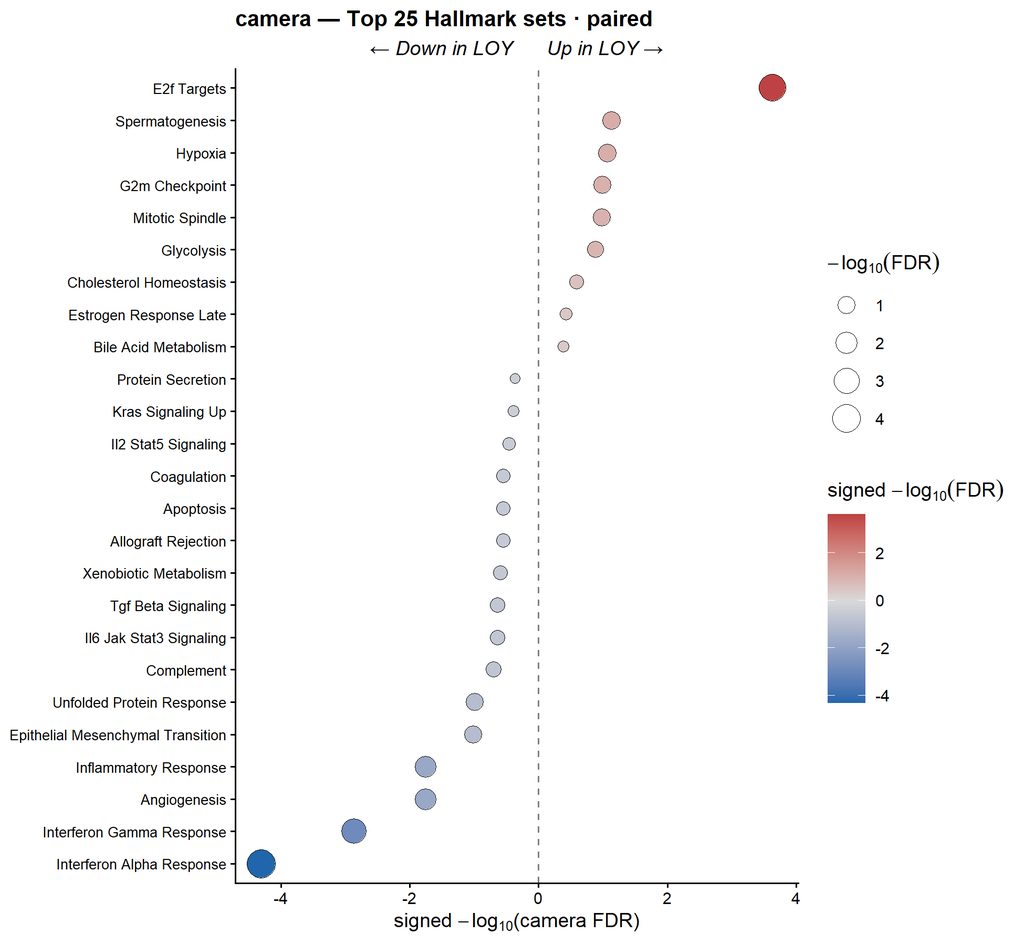

```
## Saved: camera_hallmark_dotplot_paired.(png|pdf)  [6.5x6 in]
```

### Unpaired

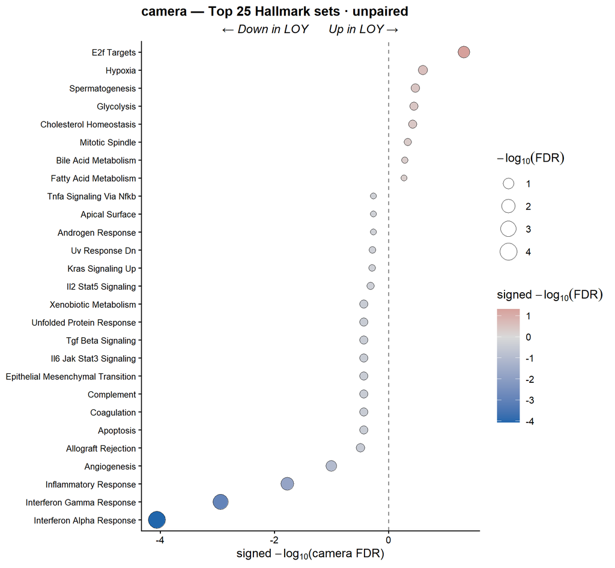

```
## Saved: camera_hallmark_dotplot_unpaired.(png|pdf)  [6.5x6 in]
```

### Pooled

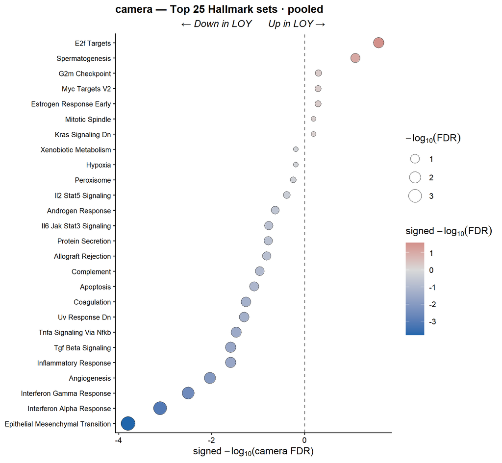

```
## Saved: camera_hallmark_dotplot_pooled.(png|pdf)  [6.5x6 in]
```

# 7. Sex-chromosome homologs / Y-linked paralog deep-dive

```
## Paralog genes detected: 18 / 20
```

```
## Missing (filtered out or unannotated):  TMSB4Y, PRKY
```

## 7.1 Per-pair boxplots

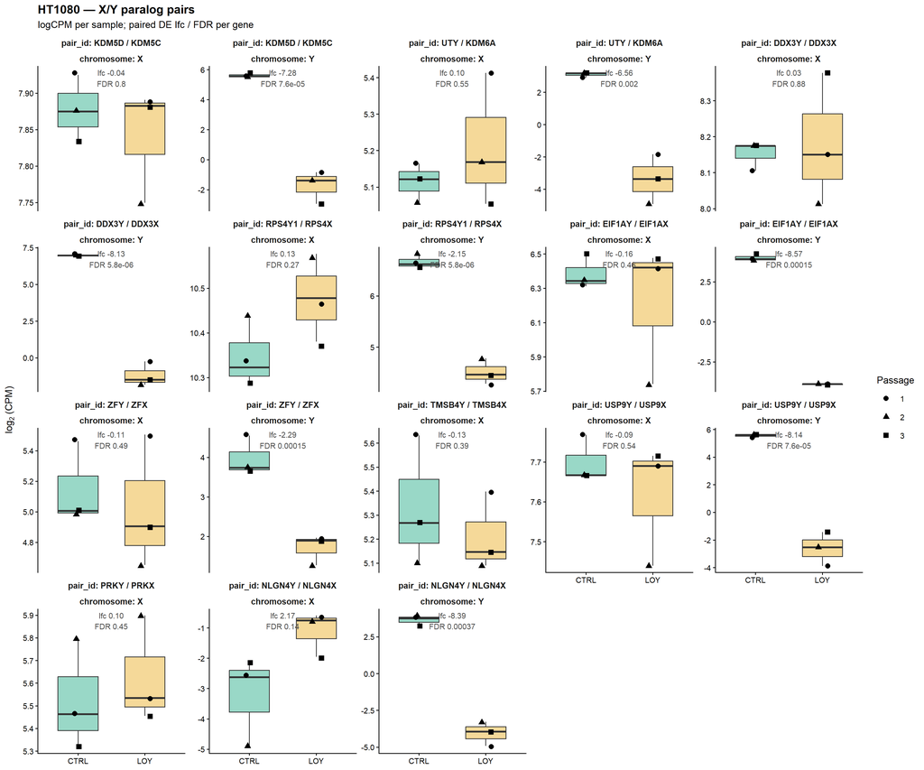

```
## Saved: paralog_boxplots.(png|pdf)  [12x10 in]
```

## 7.2 Y-gene logFC vs paralogous X-gene logFC

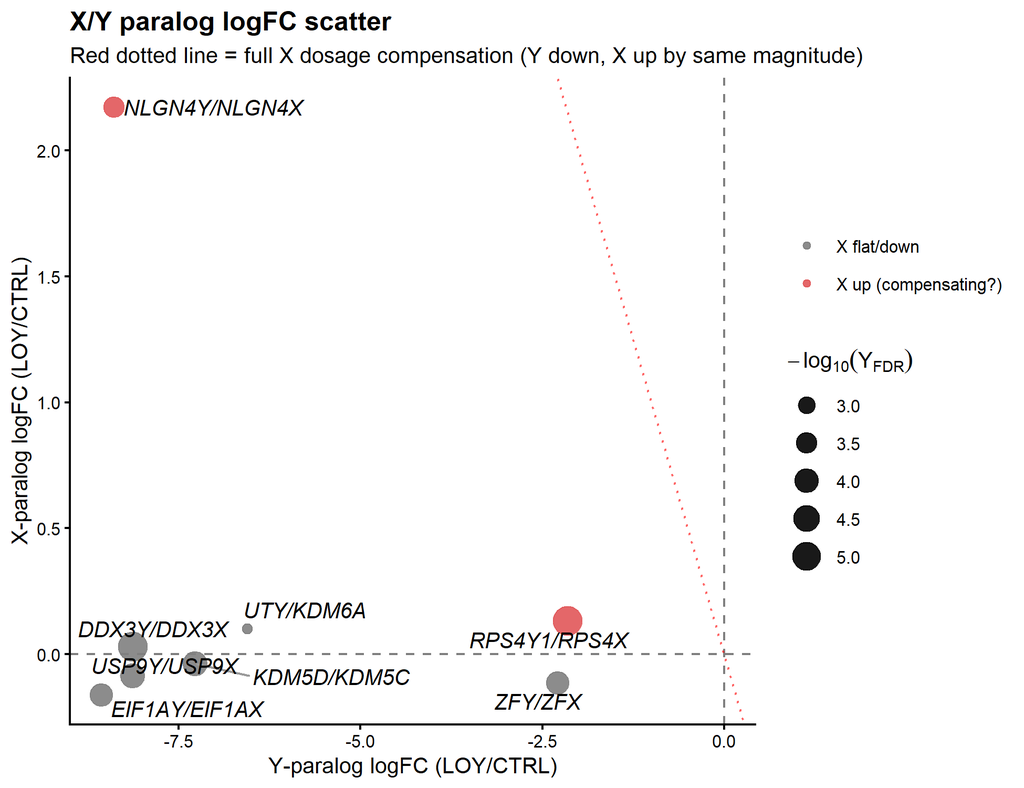

```
## Saved: paralog_logFC_scatter.(png|pdf)  [6.5x5 in]
```

## 7.3 Dosage-compensation index

X/Y paralog dosage-compensation summary

| pair | Y | Y_logFC | Y_FDR | X | X_logFC | X_FDR | compensation_index | interpretation |
| --- | --- | --- | --- | --- | --- | --- | --- | --- |
| EIF1AY/EIF1AX | EIF1AY | -8.567 | 0.000 | EIF1AX | -0.162 | 0.461 | -8.729 | X flat (no compensation) |
| NLGN4Y/NLGN4X | NLGN4Y | -8.390 | 0.000 | NLGN4X | 2.173 | 0.142 | -6.218 | X upregulated (compensating) |
| USP9Y/USP9X | USP9Y | -8.137 | 0.000 | USP9X | -0.085 | 0.541 | -8.222 | X flat (no compensation) |
| DDX3Y/DDX3X | DDX3Y | -8.132 | 0.000 | DDX3X | 0.028 | 0.877 | -8.104 | X flat (no compensation) |
| KDM5D/KDM5C | KDM5D | -7.281 | 0.000 | KDM5C | -0.037 | 0.803 | -7.317 | X flat (no compensation) |
| UTY/KDM6A | UTY | -6.556 | 0.002 | KDM6A | 0.100 | 0.548 | -6.456 | X flat (no compensation) |
| ZFY/ZFX | ZFY | -2.289 | 0.000 | ZFX | -0.114 | 0.491 | -2.403 | X flat (no compensation) |
| RPS4Y1/RPS4X | RPS4Y1 | -2.149 | 0.000 | RPS4X | 0.132 | 0.273 | -2.017 | X flat (no compensation) |
| TMSB4Y/TMSB4X | TMSB4Y | NA | NA | TMSB4X | -0.126 | 0.391 | NA | Y changed (other dir) |
| PRKY/PRKX | PRKY | NA | NA | PRKX | 0.104 | 0.453 | NA | Y changed (other dir) |

## 7.4 Paralog heatmap

Side-by-side z-scaled logCPM heatmap of the X/Y paralog pairs. The default LOY-vs-sgCTRL tab matches the rest of §7 (paired contrast working set). The “with PARENTAL” tab adds the 3 PARENTAL samples as an untreated baseline — useful for spotting whether any X/Y paralog drift in LOY also appears between PARENTAL and sgCTRL (a sgRNA artifact rather than LOY biology).

### LOY vs sgCTRL only

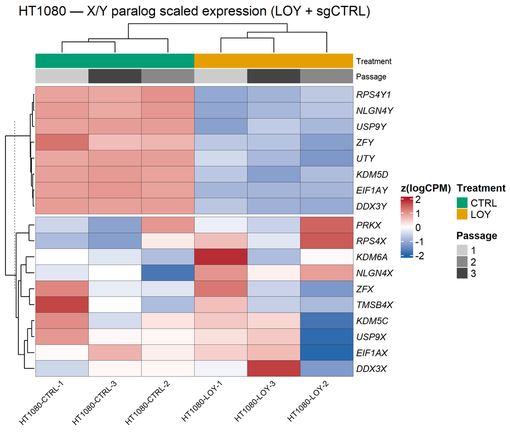

```
## Saved: paralog_heatmap.(png|pdf)
```

### With PARENTAL

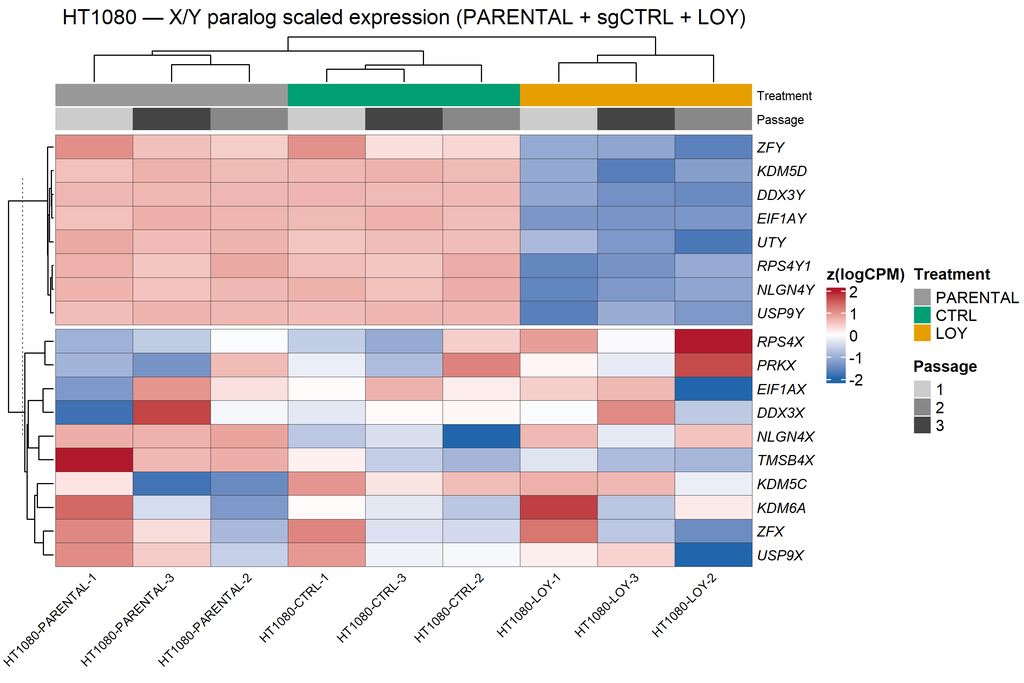

```
## Saved: paralog_heatmap_with_parental.(png|pdf)
```

# 8. Sample-level pathway scoring

Goal: instead of contrast-level enrichment, score each Hallmark / PROGENy / custom signature per sample, then test the score with the paired model.

## 8.1 GSVA / ssGSEA on Hallmark

```
## ssGSEA: 50 Hallmark sets x 6 samples
```

## 8.2 PROGENy pathway activity

```
## PROGENy: 14 pathways x 6 samples
```

## 8.3 decoupleR-PROGENy (cross-method check)

```
## decoupleR-PROGENy: 14 pathways x 6 samples
```

## 8.4 PROGENy vs decoupleR-PROGENy concordance

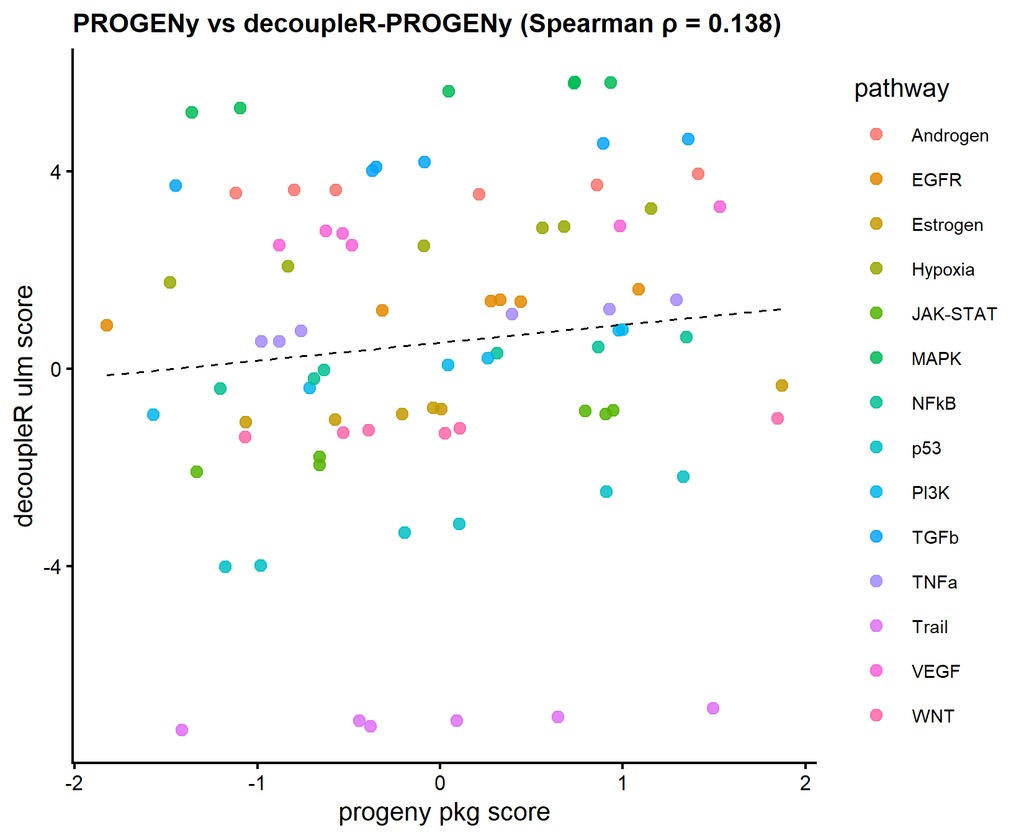

```
## Saved: progeny_vs_decoupleR_concord.(png|pdf)  [5.5x4.5 in]
```

## 8.5 Custom signatures (LOY / PRC2-bivalent / chrY)

```
## Custom signature sizes (after gene-matrix filter):
```

```
## LOY_down_top50  PRC2_bivalent    chrY_coding
##             48           1290              9
```

## 8.6 LM test on each score (paired vs unpaired)

Per-pathway score shift tested against treatment. Paired (`~ treatment + passage`) is the canonical analysis; unpaired (`~ treatment`) is the robustness comparison — agreement between the two means the passage block isn’t carrying the signal.

Note: a “pooled” LM here would require re-scoring GSVA/PROGENy on the full 9-sample DGEList (CTRL + LOY + PARENTAL). Sample-level scoring above is on the 6-sample CTRL+LOY working set, so paired/unpaired is the natural pair of tests at the score level. The DE-level pooled design is tested in §4/§5.

### Paired

```
## Top 15 sample-level pathway score shifts (paired):
```

| pathway | method | beta_LOY | SE | p_value | FDR |
| --- | --- | --- | --- | --- | --- |
| chrY_coding | ssGSEA_custom | -0.982 | 0.007 | 0.0000 | 0.0001 |
| HALLMARK_INTERFERON_GAMMA_RESPONSE | ssGSEA_hallmark | -0.018 | 0.000 | 0.0006 | 0.0282 |
| NFkB | decoupleR_PROGENy | -0.671 | 0.019 | 0.0008 | 0.0115 |
| LOY_down_top50 | ssGSEA_custom | -0.902 | 0.040 | 0.0019 | 0.0029 |
| TNFa | decoupleR_PROGENy | -0.614 | 0.031 | 0.0026 | 0.0180 |
| HALLMARK_MITOTIC_SPINDLE | ssGSEA_hallmark | 0.012 | 0.001 | 0.0043 | 0.1087 |
| JAK-STAT | decoupleR_PROGENy | -1.071 | 0.085 | 0.0063 | 0.0292 |
| TGFb | PROGENy | -1.254 | 0.105 | 0.0069 | 0.0482 |
| NFkB | PROGENy | -1.686 | 0.151 | 0.0079 | 0.0482 |
| JAK-STAT | PROGENy | -1.767 | 0.181 | 0.0103 | 0.0482 |
| HALLMARK_INFLAMMATORY_RESPONSE | ssGSEA_hallmark | -0.014 | 0.002 | 0.0127 | 0.1450 |
| HALLMARK_INTERFERON_ALPHA_RESPONSE | ssGSEA_hallmark | -0.029 | 0.004 | 0.0149 | 0.1450 |
| HALLMARK_TNFA_SIGNALING_VIA_NFKB | ssGSEA_hallmark | -0.008 | 0.001 | 0.0181 | 0.1450 |
| TNFa | PROGENy | -1.745 | 0.240 | 0.0184 | 0.0643 |
| TGFb | decoupleR_PROGENy | -0.418 | 0.060 | 0.0203 | 0.0576 |

### Unpaired

```
## Top 15 sample-level pathway score shifts (unpaired):
```

| pathway | method | beta_LOY | SE | p_value | FDR |
| --- | --- | --- | --- | --- | --- |
| chrY_coding | ssGSEA_custom | -0.982 | 0.010 | 0.0000 | 0.0000 |
| LOY_down_top50 | ssGSEA_custom | -0.902 | 0.061 | 0.0001 | 0.0002 |
| JAK-STAT | decoupleR_PROGENy | -1.071 | 0.092 | 0.0003 | 0.0044 |
| JAK-STAT | PROGENy | -1.767 | 0.229 | 0.0015 | 0.0204 |
| TNFa | PROGENy | -1.745 | 0.269 | 0.0029 | 0.0204 |
| TNFa | decoupleR_PROGENy | -0.614 | 0.113 | 0.0056 | 0.0392 |
| NFkB | PROGENy | -1.686 | 0.350 | 0.0085 | 0.0399 |
| NFkB | decoupleR_PROGENy | -0.671 | 0.143 | 0.0094 | 0.0438 |
| HALLMARK_INTERFERON_GAMMA_RESPONSE | ssGSEA_hallmark | -0.018 | 0.005 | 0.0225 | 0.7109 |
| HALLMARK_INTERFERON_ALPHA_RESPONSE | ssGSEA_hallmark | -0.029 | 0.009 | 0.0284 | 0.7109 |
| HALLMARK_IL2_STAT5_SIGNALING | ssGSEA_hallmark | -0.013 | 0.006 | 0.0848 | 0.8163 |
| HALLMARK_KRAS_SIGNALING_DN | ssGSEA_hallmark | 0.004 | 0.002 | 0.1232 | 0.8163 |
| TGFb | PROGENy | -1.254 | 0.663 | 0.1317 | 0.4611 |
| PRC2_bivalent | ssGSEA_custom | 0.026 | 0.014 | 0.1444 | 0.1444 |
| HALLMARK_COMPLEMENT | ssGSEA_hallmark | -0.011 | 0.006 | 0.1531 | 0.8163 |

## 8.7 Heatmap of Hallmark scores

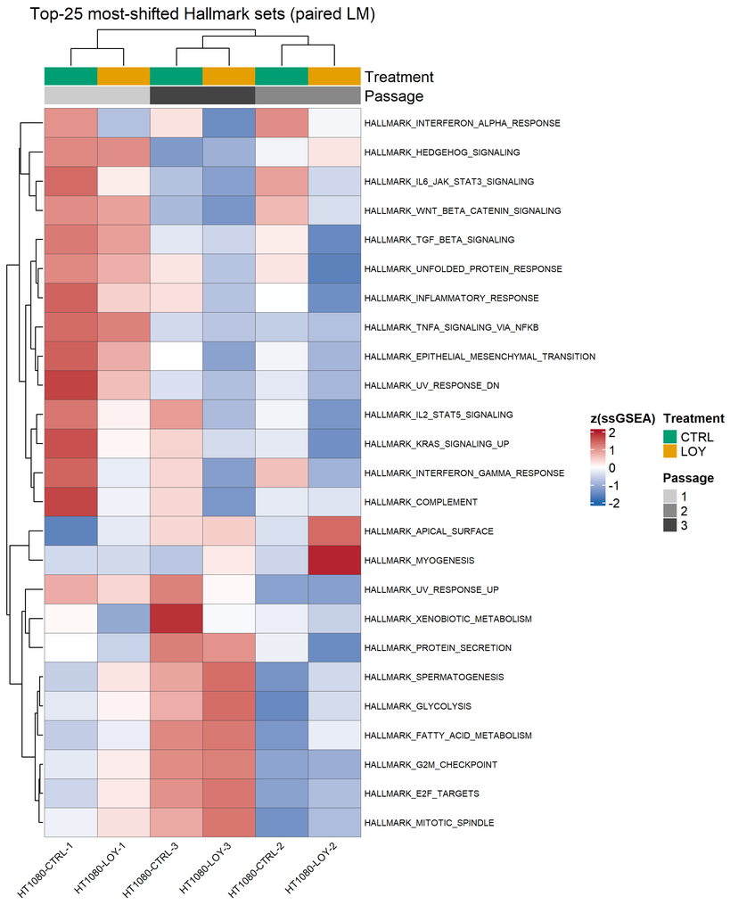

## 8.8 Top-6 score boxplots

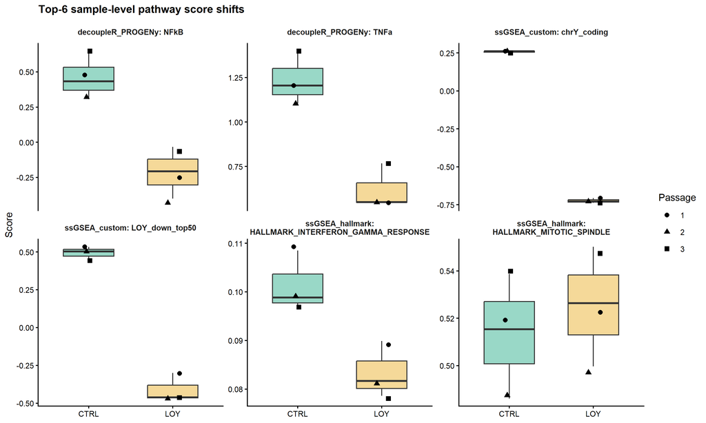

```
## Saved: top6_pathway_score_boxplots.(png|pdf)  [10x6 in]
```

# 9. lpWGS copy-number integration

**Data**: HT1080 lpWGS (`HT1080-sgCTRL-D0`, `HT1080-LOY-D0` — n=1 per arm, single timepoint, T2T-CHM13v2.0). Pre-segmented by QDNAseq in `projects/WGS/code/coverage_report_HT1080_QDNAseq.Rmd`, exported as `HT1080_QDNAseq_cn.rds` + `HT1080_QDNAseq_cn_df.rds`. The n=1-per-arm constraint means CN is treated as a **population backdrop** for the RNAseq contrast — not per-replicate matched.

## 9.1 Load CN object

```
## Loaded CN: 31185 bins x 2 samples (T2T-CHM13)
```

```
## [1] sgCTRL LOY
## Levels: sgCTRL LOY
```

## 9.2 Build T2T-CHM13 gene coordinate index

```
## Loading T2T-CHM13v2.0 GTF (may take ~30s)...
```

```
## T2T gene index: 57711 genes across chroms chr1,chr2,chr3,chr4,chr5,chr6,chr7,chr8,chr9,chr10,chr11,chr12,chr13,chr14,chr15,chr16,chr17,chr18,chr19,chr20,chr21,chr22,chrX,chrY
```

## 9.3 Overlap RNA genes onto QDNAseq bins

```
## Genes with CN mapping: 14862 / 16011 in DE
```

## 9.4 Annotate DE table with CN

```
## DEGs (FDR<0.05) flagged as CN-driven:  42  /  1149
```

## 9.5 DEG volcano colored by CN state — cutoff sweep

The classifier compares each gene’s lpWGS `cn_delta = log2(LOY/sgCTRL)` at its bin to a Gain/Loss cutoff. The sensible range is 0.3–0.5 (0.3 ≈ 1.23× signal shift, 0.5 ≈ 1.41× shift). Three tabs at 0.3 / 0.4 / 0.5; tighter cutoffs keep only the most confident CN shifts. The 3-across composite is also saved to disk as `volcano_LOY_v_sgCTRL_cn_cutoff_sweep.(png|pdf)`.

```
## Saved: volcano_LOY_v_sgCTRL_cn_cutoff_sweep.(png|pdf)  [18x6 in]
```

### |cn_delta| > 0.3

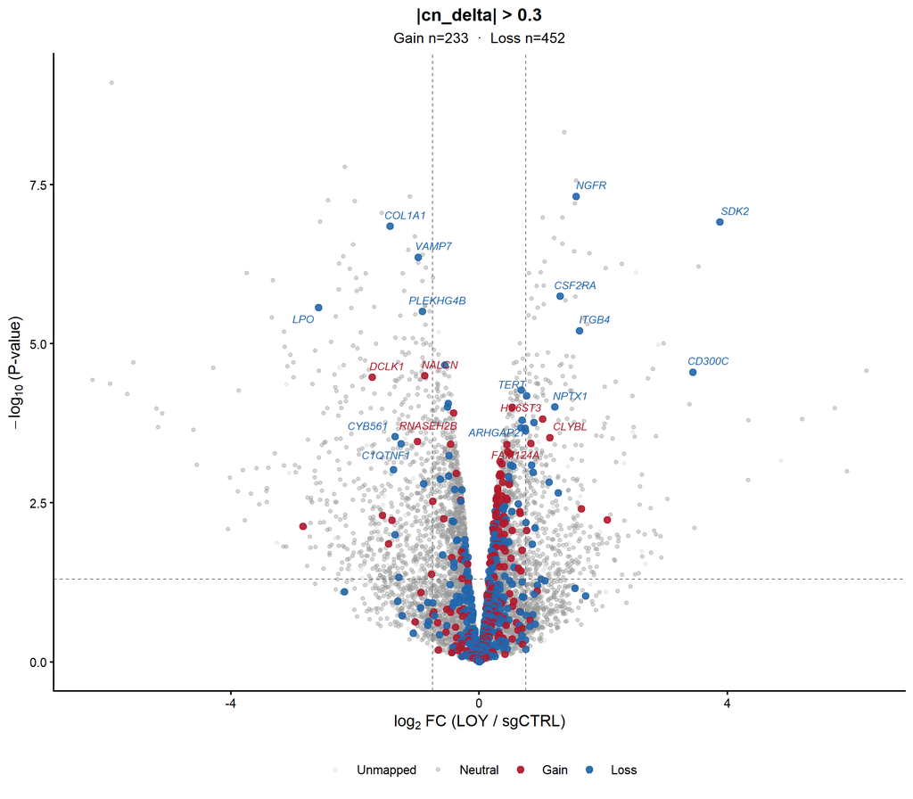

### |cn_delta| > 0.4

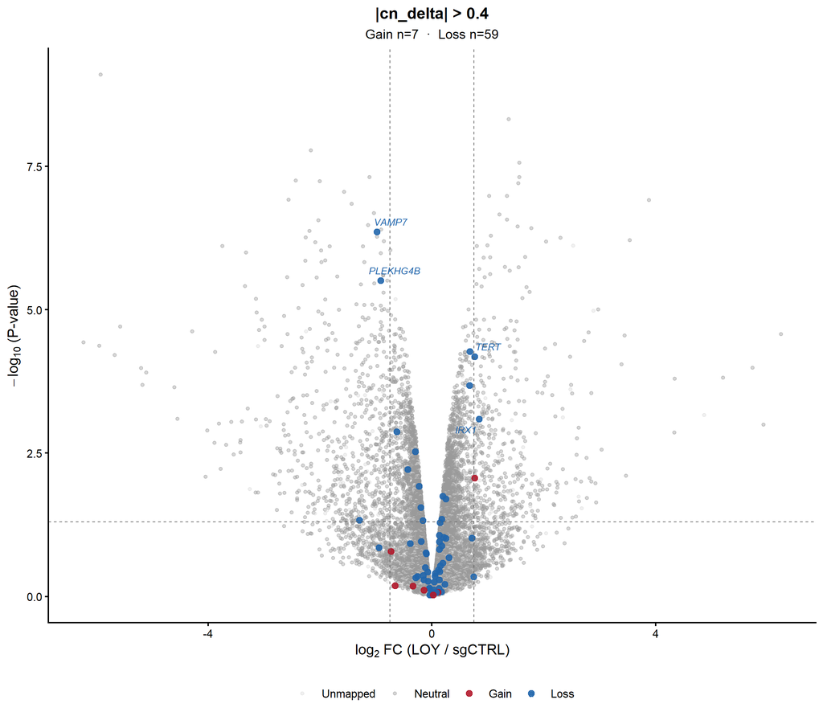

### |cn_delta| > 0.5

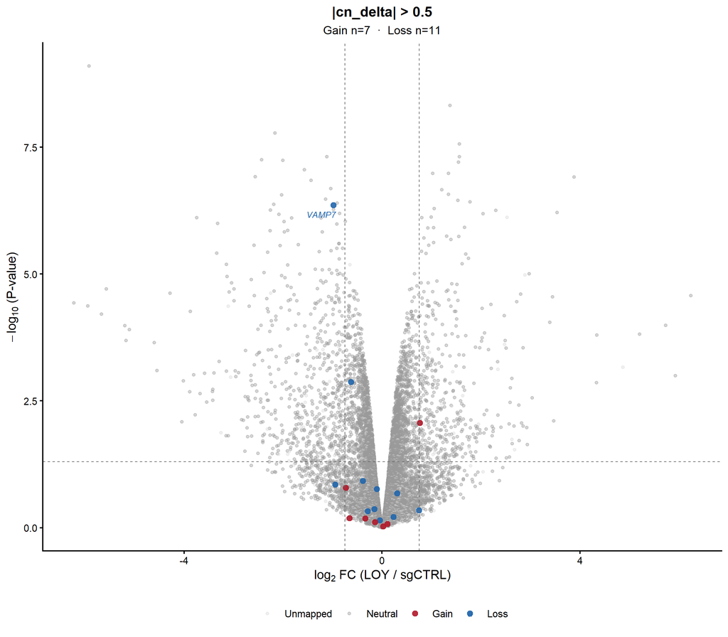

### Gene counts by cutoff

Gene counts by cn_delta cutoff (Gain_among_sig / Loss_among_sig restricted to FDR<0.05 & |logFC|>0.75)

| cutoff | Gain | Loss | Neutral | Unmapped | Gain_among_sig | Loss_among_sig |
| --- | --- | --- | --- | --- | --- | --- |
| 0.3 | 233 | 452 | 14181 | 1149 | 6 | 20 |
| 0.4 | 7 | 59 | 14800 | 1149 | 0 | 4 |
| 0.5 | 7 | 11 | 14848 | 1149 | 0 | 1 |

## 9.6 Chromosome-arm mean shifts

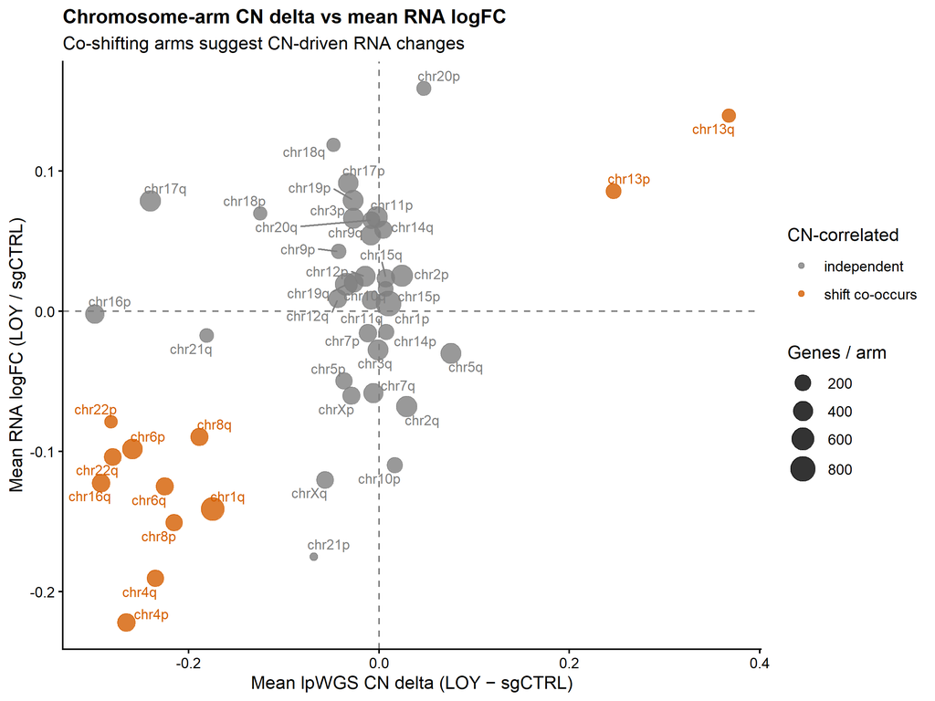

```
## Saved: chromosome_arm_CN_vs_RNA.(png|pdf)  [8x6 in]
```